# APG Pertemuan-3 kelas 3SI1

Riofebri Prasetia (221911192)

3/3/2022

## Library dan Dataset

### Library

```r
library('MVN')
library('mvoutlier')
library('evd')
library('RVAideMemoire')
```

### Dataset

```r
url <- "https://raw.githubusercontent.com/rii92/tugas-APG/main/6%20maret%202022/tugas%20ketiga%20APG.csv"
data1<-read.csv(url)
data1
```

```
##    Fuel.x1. Repair.x2. Capital.x3.
## 1     16.44      12.43       11.23
## 2      7.19       2.70        3.92
## 3      9.92       1.35        9.75
## 4      4.24       5.78        7.78
## 5     11.20       5.05       10.67
## 6     14.25       5.78        9.88
## 7     13.50      10.98       10.60
## 8     13.32      14.27        9.45
## 9     29.11      15.09        3.28
## 10    12.68       7.61       10.23
## 11     7.51       5.80        8.13
## 12     9.90       3.63        9.13
## 13    10.25       5.07       10.17
## 14    11.11       6.15        7.61
## 15    12.17      14.26       14.39
## 16    10.24       2.59        6.09
## 17    10.18       6.05       12.14
## 18     8.88       2.70       12.23
## 19    12.34       7.73       11.68
## 20     8.51      14.02       12.01
## 21    26.16      17.44       16.89
## 22    12.95       8.24        7.18
## 23    16.93      13.37       17.59
## 24    14.70      10.78       14.58
## 25    10.32       5.16       17.00
```

Data ini merepresentasikan berabgai biaya terkait pengangkutan susu dan peternakan ke pabrik susu untuk truk bensin. observasi ke 9 dan 21 telah diidentifikasi sebagai outlier

## Deteksi Outlier dengan Beberapa Metode

### Scatter Plot Bivariate

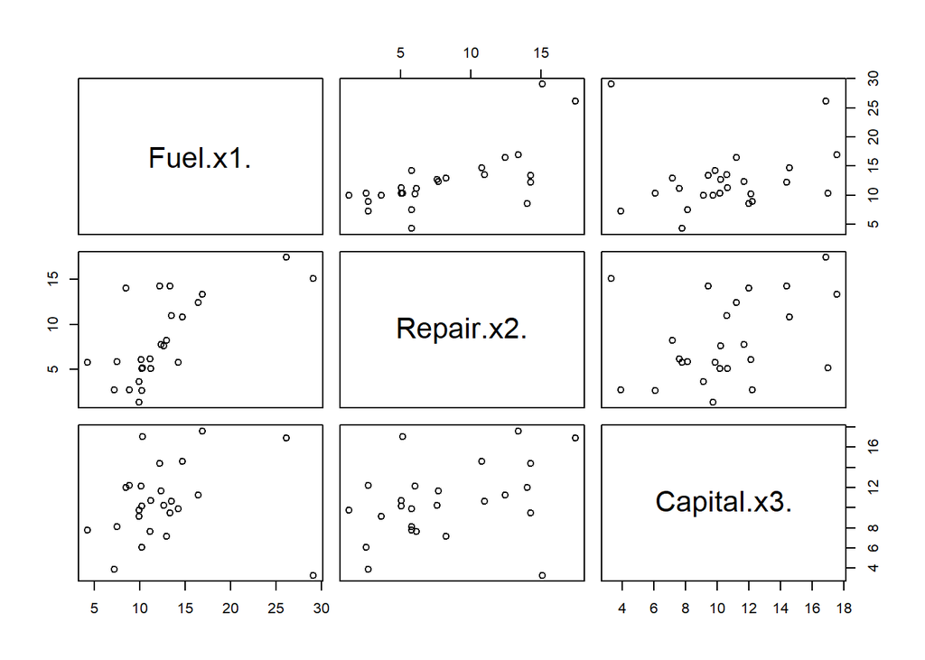

```r
pairs(data1)
```

### Chi-square Plot

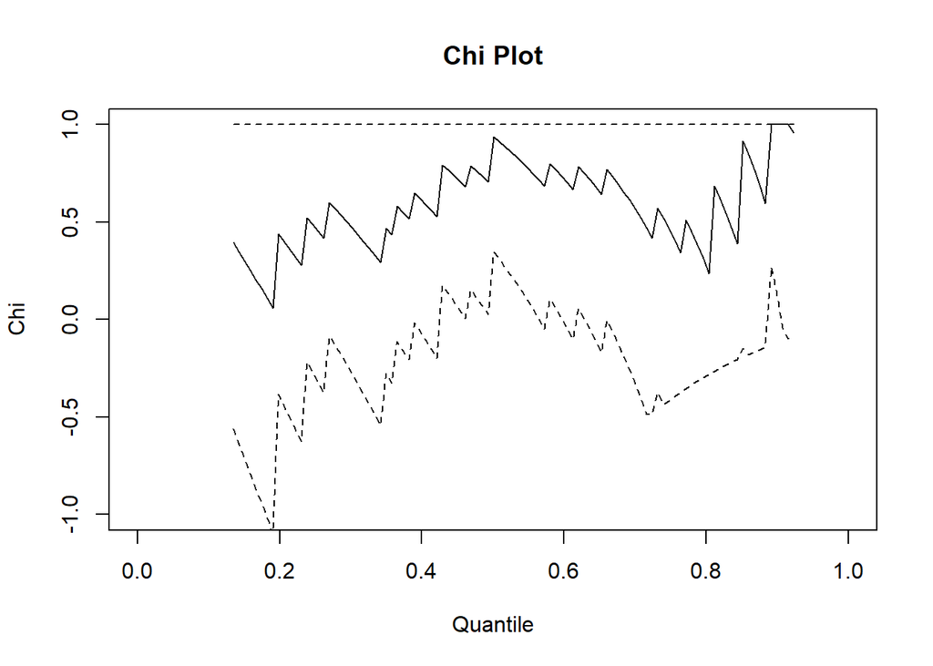

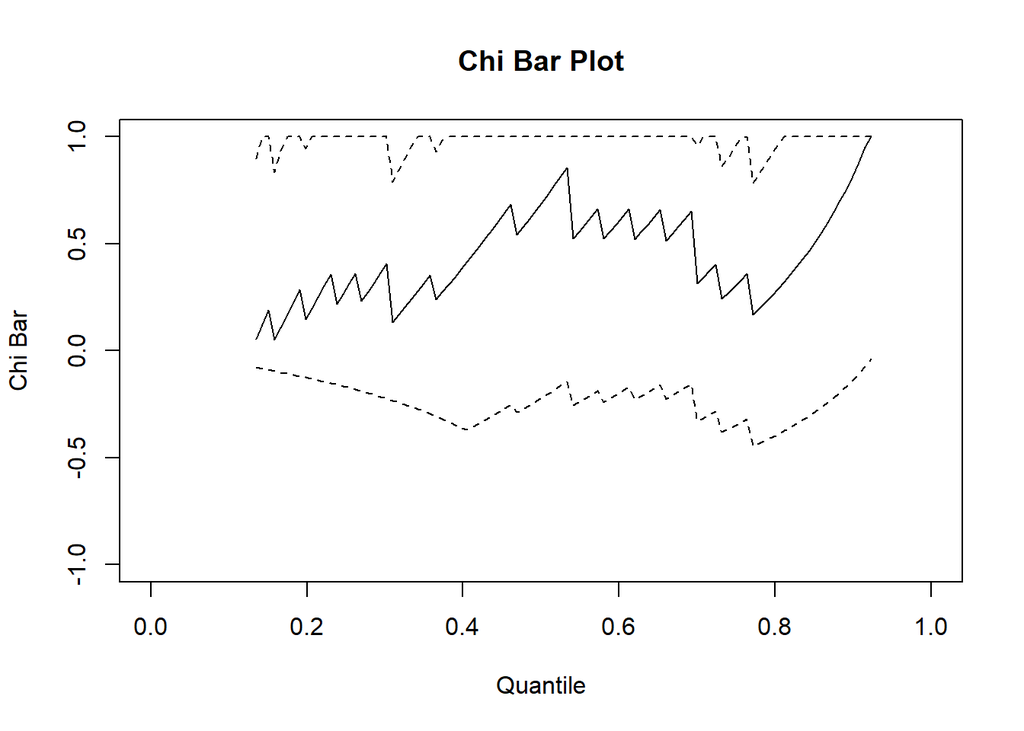

```r
chiplot(data1)
```

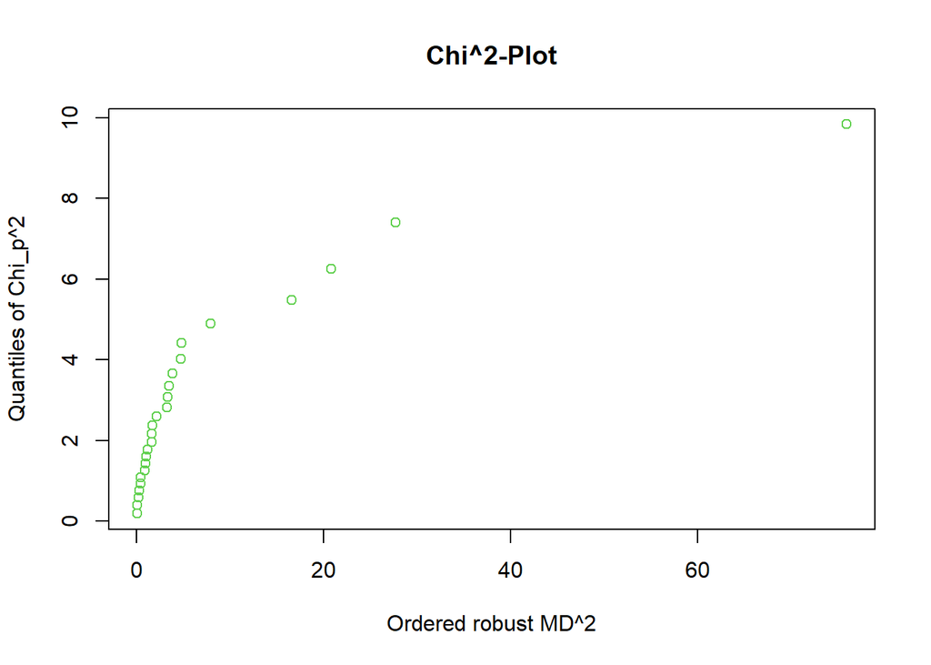

```
## Remove outliers with left-click, stop with right-click on plotting device
```

```r
chisq.plot(data1)
```

### Q-Q Plot Univariate

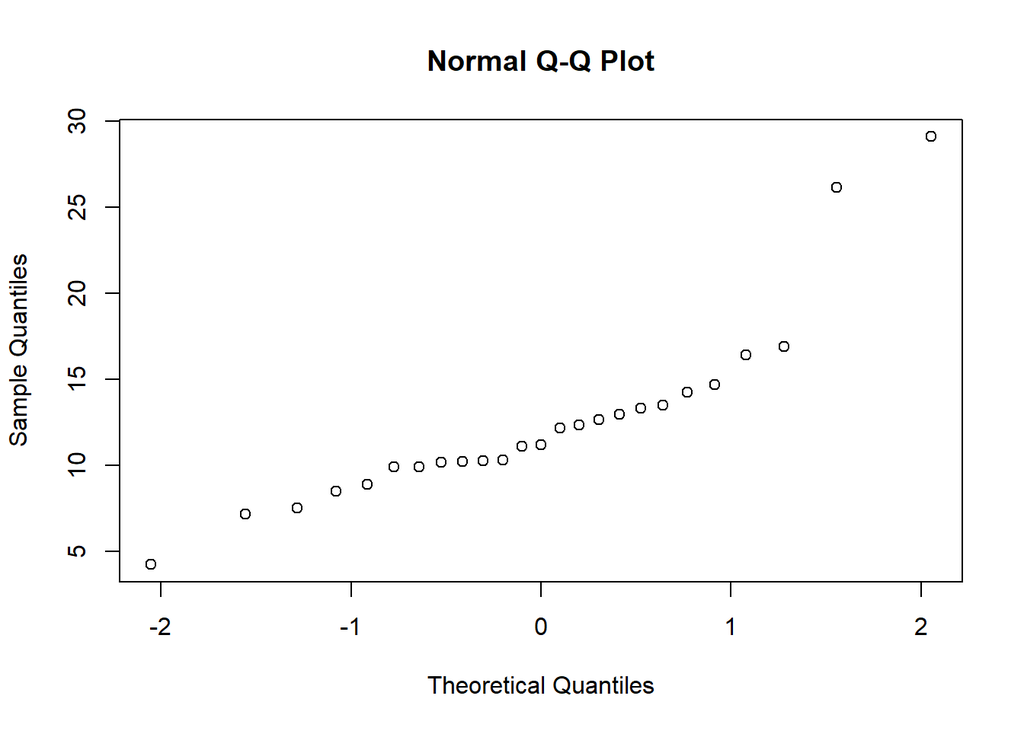

```r
qqnorm(data1$Fuel.x1.)
```

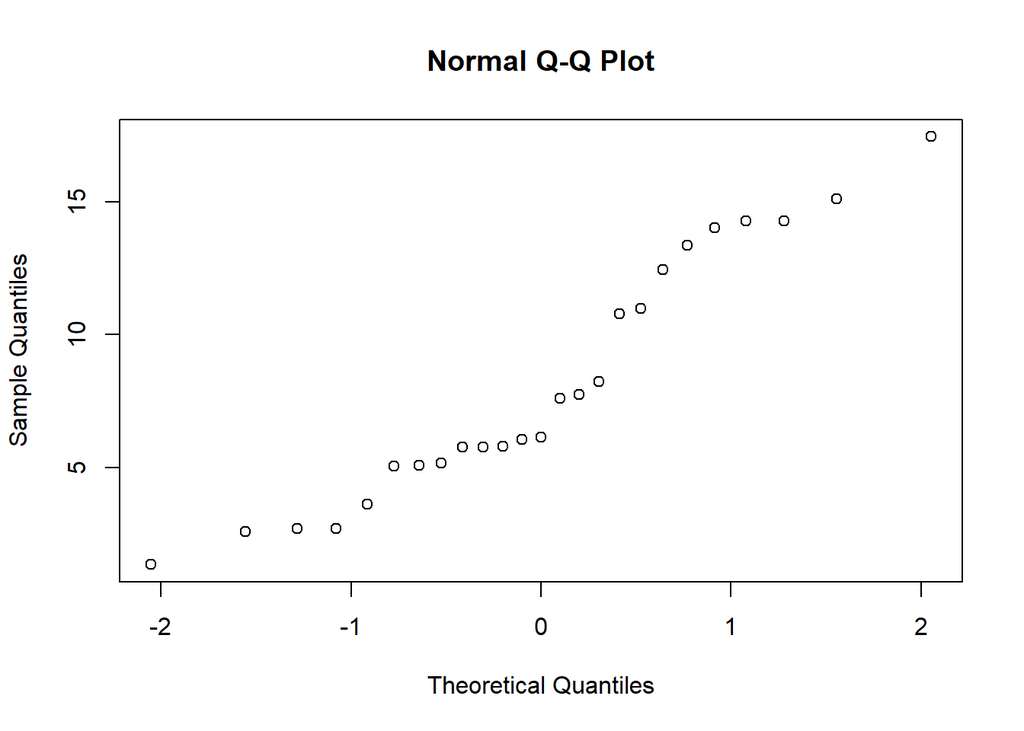

```r
qqnorm(data1$Repair.x2.)
```

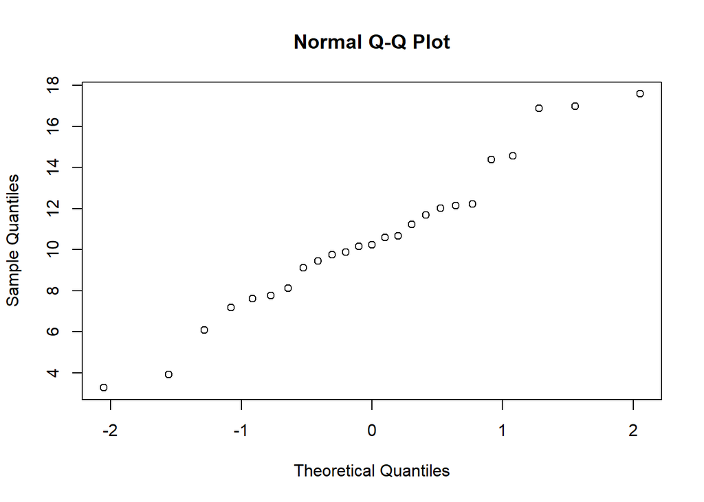

```r
qqnorm(data1$Capital.x3.)
```

Interpretasi dari deteksi outlier: sejauh ini secara multivariate, terdapat 3 observasi dimana 1 dari ke-3 observasi tersebut merupakan outlier paling jauh jika dilihat dari diagram chi-quadrat plot. secara univariate, pada variabel bahan bakar (fuel) terlihat sebanyak 2 outlier, pada variabel perbaikan (repair) terdapat 1 outlier, sedangkan pada variabel modal (capital) terdapat 3 outlier. Hal ini jika di lakukan drop outlier maka akan ada informasi yang hilang antara variabel bahan bakar (fuel) dan perbaikan (repair). Sehingga dalam melakukan drop outlier perlu mempertimbangkan hal tersebut

## Uji Multivariate Normal dengan beberapa metode

### Mardia’s MVN test:

```r
set.seed(1000)
mvn(data1, mvnTest = 'mardia', showOutliers = TRUE)
```

```
## $multivariateNormality
##              Test        Statistic              p value Result
## 1 Mardia Skewness 31.0703714747092 0.000571228046555686     NO
## 2 Mardia Kurtosis 2.60029957463255  0.00931424099011013     NO
## 3             MVN             <NA>                 <NA>     NO
##
## $univariateNormality
##               Test    Variable Statistic   p value Normality
## 1 Anderson-Darling  Fuel.x1.      1.4744    0.0006    NO
## 2 Anderson-Darling Repair.x2.     0.7740    0.0383    NO
## 3 Anderson-Darling Capital.x3.    0.3049    0.5434    YES
##
## $Descriptives
##              n    Mean  Std.Dev Median  Min   Max 25th  75th      Skew
## Fuel.x1.    25 12.5600 5.382000  11.20 4.24 29.11 9.92 13.50 1.5749453
## Repair.x2.  25  8.1612 4.631722   6.15 1.35 17.44 5.07 12.43 0.4003681
## Capital.x3. 25 10.5444 3.687688  10.23 3.28 17.59 8.13 12.14 0.1154018
##               Kurtosis
## Fuel.x1.     2.5684509
## Repair.x2.  -1.2126908
## Capital.x3. -0.4623851
##
## $multivariateOutliers
## NULL
```

### Henze-Zirkler’s MVN test:

```r
set.seed(1000)
mvn(data1, showOutliers = TRUE)
```

```
## $multivariateNormality
##            Test        HZ    p value MVN
## 1 Henze-Zirkler 0.9917324 0.01155811  NO
##
## $univariateNormality
##               Test    Variable Statistic   p value Normality
## 1 Anderson-Darling  Fuel.x1.      1.4744    0.0006    NO
## 2 Anderson-Darling Repair.x2.     0.7740    0.0383    NO
## 3 Anderson-Darling Capital.x3.    0.3049    0.5434    YES
##
## $Descriptives
##              n    Mean  Std.Dev Median  Min   Max 25th  75th      Skew
## Fuel.x1.    25 12.5600 5.382000  11.20 4.24 29.11 9.92 13.50 1.5749453
## Repair.x2.  25  8.1612 4.631722   6.15 1.35 17.44 5.07 12.43 0.4003681
## Capital.x3. 25 10.5444 3.687688  10.23 3.28 17.59 8.13 12.14 0.1154018
##               Kurtosis
## Fuel.x1.     2.5684509
## Repair.x2.  -1.2126908
## Capital.x3. -0.4623851
##
## $multivariateOutliers
## NULL
```

### Royston’s MVN test:

```r
set.seed(1000)
mvn(data1, mvnTest = 'royston', showOutliers = TRUE)
```

```
## $multivariateNormality
##      Test        H     p value MVN
## 1 Royston 16.25651 0.001011804  NO
##
## $univariateNormality
##               Test    Variable Statistic   p value Normality
## 1 Anderson-Darling  Fuel.x1.      1.4744    0.0006    NO
## 2 Anderson-Darling Repair.x2.     0.7740    0.0383    NO
## 3 Anderson-Darling Capital.x3.    0.3049    0.5434    YES
##
## $Descriptives
##              n    Mean  Std.Dev Median  Min   Max 25th  75th      Skew
## Fuel.x1.    25 12.5600 5.382000  11.20 4.24 29.11 9.92 13.50 1.5749453
## Repair.x2.  25  8.1612 4.631722   6.15 1.35 17.44 5.07 12.43 0.4003681
## Capital.x3. 25 10.5444 3.687688  10.23 3.28 17.59 8.13 12.14 0.1154018
##               Kurtosis
## Fuel.x1.     2.5684509
## Repair.x2.  -1.2126908
## Capital.x3. -0.4623851
##
## $multivariateOutliers
## NULL
```

### E-Statistics Test:

```r
set.seed(1000)
mvn(data1, mvnTest = 'energy')
```

```
## $multivariateNormality
##          Test Statistic p value MVN
## 1 E-statistic  1.301165   0.003  NO
##
## $univariateNormality
##               Test    Variable Statistic   p value Normality
## 1 Anderson-Darling  Fuel.x1.      1.4744    0.0006    NO
## 2 Anderson-Darling Repair.x2.     0.7740    0.0383    NO
## 3 Anderson-Darling Capital.x3.    0.3049    0.5434    YES
##
## $Descriptives
##              n    Mean  Std.Dev Median  Min   Max 25th  75th      Skew
## Fuel.x1.    25 12.5600 5.382000  11.20 4.24 29.11 9.92 13.50 1.5749453
## Repair.x2.  25  8.1612 4.631722   6.15 1.35 17.44 5.07 12.43 0.4003681
## Capital.x3. 25 10.5444 3.687688  10.23 3.28 17.59 8.13 12.14 0.1154018
##               Kurtosis
## Fuel.x1.     2.5684509
## Repair.x2.  -1.2126908
## Capital.x3. -0.4623851
```

### Shapiro-Wilk Test:

```r
set.seed(1000)
mshapiro.test(data1)
```

```
##
##  Multivariate Shapiro-Wilk normality test
##
## data:  (Fuel.x1.,Repair.x2.,Capital.x3.)
## W = 0.77297, p-value = 8.319e-05
```

Interpretasi dari uji multivariate normal dengan beberapa metode: Berdasarkan uji multivariate normal dengan beberapa metode maka bisa disimpulkan bahwa data pengangkutan susu dari peternakan tidak berdistribusi normal secara multivariate. Hal ini bisa di pengaruhi oleh outlier atau data harus di transformasi ke dalam bentuk lain.

## Lakukan remove jika ada outlier, transformasi dan test multivariate normal

## Melakukan pembuangan atau drop outlier kemudian test multivariate normal:

```r
Q1 <- quantile(data1$Fuel.x1., .25)
Q3 <- quantile(data1$Fuel.x1., .75)
IQR <- (Q3 - Q1)

upper_bound <- Q3 + (IQR * 1.5)
lower_bound <- Q1 - (IQR * 1.5)

eliminated <- subset(data1, data1$Fuel.x1. > lower_bound & data1$Fuel.x1. < upper_bound)

eliminated
```

```
##    Fuel.x1. Repair.x2. Capital.x3.
## 1     16.44      12.43       11.23
## 2      7.19       2.70        3.92
## 3      9.92       1.35        9.75
## 5     11.20       5.05       10.67
## 6     14.25       5.78        9.88
## 7     13.50      10.98       10.60
## 8     13.32      14.27        9.45
## 10    12.68       7.61       10.23
## 11     7.51       5.80        8.13
## 12     9.90       3.63        9.13
## 13    10.25       5.07       10.17
## 14    11.11       6.15        7.61
## 15    12.17      14.26       14.39
## 16    10.24       2.59        6.09
## 17    10.18       6.05       12.14
## 18     8.88       2.70       12.23
## 19    12.34       7.73       11.68
## 20     8.51      14.02       12.01
## 22    12.95       8.24        7.18
## 23    16.93      13.37       17.59
## 24    14.70      10.78       14.58
## 25    10.32       5.16       17.00
```

### Mardia’s MVN test:

```r
set.seed(1000)
mvn(eliminated, mvnTest = 'mardia', showOutliers = TRUE)
```

```
## $multivariateNormality
##              Test           Statistic           p value Result
## 1 Mardia Skewness     9.4868942940147 0.486600705559608    YES
## 2 Mardia Kurtosis -0.0396707311020114 0.968355636497569    YES
## 3             MVN                <NA>              <NA>    YES
##
## $univariateNormality
##               Test    Variable Statistic   p value Normality
## 1 Anderson-Darling  Fuel.x1.      0.2420    0.7402    YES
## 2 Anderson-Darling Repair.x2.     0.6709    0.0688    YES
## 3 Anderson-Darling Capital.x3.    0.3077    0.5335    YES
##
## $Descriptives
##              n      Mean  Std.Dev Median  Min   Max  25th    75th      Skew
## Fuel.x1.    22 11.567727 2.631639 11.155 7.19 16.93 9.985 13.2275 0.2991707
## Repair.x2.  22  7.532727 4.177060  6.100 1.35 14.27 5.055 10.9300 0.3572659
## Capital.x3. 22 10.711818 3.273853 10.415 3.92 17.59 9.210 12.1075 0.2338098
##               Kurtosis
## Fuel.x1.    -0.7512962
## Repair.x2.  -1.3003991
## Capital.x3. -0.1871699
##
## $multivariateOutliers
## NULL
```

### Henze-Zirkler’s MVN test:

```r
set.seed(1000)
mvn(eliminated, showOutliers = TRUE)
```

```
## $multivariateNormality
##            Test        HZ   p value MVN
## 1 Henze-Zirkler 0.5777932 0.4674496 YES
##
## $univariateNormality
##               Test    Variable Statistic   p value Normality
## 1 Anderson-Darling  Fuel.x1.      0.2420    0.7402    YES
## 2 Anderson-Darling Repair.x2.     0.6709    0.0688    YES
## 3 Anderson-Darling Capital.x3.    0.3077    0.5335    YES
##
## $Descriptives
##              n      Mean  Std.Dev Median  Min   Max  25th    75th      Skew
## Fuel.x1.    22 11.567727 2.631639 11.155 7.19 16.93 9.985 13.2275 0.2991707
## Repair.x2.  22  7.532727 4.177060  6.100 1.35 14.27 5.055 10.9300 0.3572659
## Capital.x3. 22 10.711818 3.273853 10.415 3.92 17.59 9.210 12.1075 0.2338098
##               Kurtosis
## Fuel.x1.    -0.7512962
## Repair.x2.  -1.3003991
## Capital.x3. -0.1871699
##
## $multivariateOutliers
## NULL
```

### Royston’s MVN test:

```r
set.seed(1000)
mvn(eliminated, mvnTest = 'royston', showOutliers = TRUE)
```

```
## $multivariateNormality
##      Test        H   p value MVN
## 1 Royston 3.916677 0.2812111 YES
##
## $univariateNormality
##               Test    Variable Statistic   p value Normality
## 1 Anderson-Darling  Fuel.x1.      0.2420    0.7402    YES
## 2 Anderson-Darling Repair.x2.     0.6709    0.0688    YES
## 3 Anderson-Darling Capital.x3.    0.3077    0.5335    YES
##
## $Descriptives
##              n      Mean  Std.Dev Median  Min   Max  25th    75th      Skew
## Fuel.x1.    22 11.567727 2.631639 11.155 7.19 16.93 9.985 13.2275 0.2991707
## Repair.x2.  22  7.532727 4.177060  6.100 1.35 14.27 5.055 10.9300 0.3572659
## Capital.x3. 22 10.711818 3.273853 10.415 3.92 17.59 9.210 12.1075 0.2338098
##               Kurtosis
## Fuel.x1.    -0.7512962
## Repair.x2.  -1.3003991
## Capital.x3. -0.1871699
##
## $multivariateOutliers
## NULL
```

### E-Statistics Test:

```r
set.seed(1000)
mvn(eliminated, mvnTest = 'energy')
```

```
## $multivariateNormality
##          Test Statistic p value MVN
## 1 E-statistic 0.8387935   0.382 YES
##
## $univariateNormality
##               Test    Variable Statistic   p value Normality
## 1 Anderson-Darling  Fuel.x1.      0.2420    0.7402    YES
## 2 Anderson-Darling Repair.x2.     0.6709    0.0688    YES
## 3 Anderson-Darling Capital.x3.    0.3077    0.5335    YES
##
## $Descriptives
##              n      Mean  Std.Dev Median  Min   Max  25th    75th      Skew
## Fuel.x1.    22 11.567727 2.631639 11.155 7.19 16.93 9.985 13.2275 0.2991707
## Repair.x2.  22  7.532727 4.177060  6.100 1.35 14.27 5.055 10.9300 0.3572659
## Capital.x3. 22 10.711818 3.273853 10.415 3.92 17.59 9.210 12.1075 0.2338098
##               Kurtosis
## Fuel.x1.    -0.7512962
## Repair.x2.  -1.3003991
## Capital.x3. -0.1871699
```

### Shapiro-Wilk Test:

```r
set.seed(1000)
mshapiro.test(eliminated)
```

```
##
##  Multivariate Shapiro-Wilk normality test
##
## data:  (Fuel.x1.,Repair.x2.,Capital.x3.)
## W = 0.87125, p-value = 0.008261
```

Interpretasi dari uji multivariate normal dengan beberapa metode dan outlier di buang: Berdasarkan uji multivariate normal dengan beberapa metode sebagian besar metode menyimpulkan bahwa data pengangkutan susu dari peternakan secara multivariate berdistribusi normal. Akan tetapi pada uji shapiro wilk didapat p-value = 0.008 < 0.05 yang artinya data tidak berdistribusi normal secara multivariate.

## melakukan transformasi akar 5 kemudian tes multivariate normal:

```r
datatransf <- (data1*10)^(1/5)
```

### Mardia’s MVN test:

```r
set.seed(1000)
mvn(datatransf, mvnTest = 'mardia', showOutliers = TRUE)
```

```
## $multivariateNormality
##              Test        Statistic             p value Result
## 1 Mardia Skewness 26.8671647930658 0.00273334721755532     NO
## 2 Mardia Kurtosis 2.66137546792555 0.00778221223856446     NO
## 3             MVN             <NA>                <NA>     NO
##
## $univariateNormality
##               Test    Variable Statistic   p value Normality
## 1 Anderson-Darling  Fuel.x1.      0.6494    0.0797    YES
## 2 Anderson-Darling Repair.x2.     0.4336    0.2789    YES
## 3 Anderson-Darling Capital.x3.    0.4916    0.1993    YES
##
## $Descriptives
##              n     Mean   Std.Dev   Median      Min      Max     25th     75th
## Fuel.x1.    25 2.597565 0.2040257 2.569470 2.115793 3.110344 2.507854 2.667269
## Repair.x2.  25 2.343962 0.2992640 2.279161 1.682933 2.807432 2.192813 2.623579
## Capital.x3. 25 2.511177 0.1965209 2.523336 2.009901 2.812245 2.410006 2.611222
##                   Skew   Kurtosis
## Fuel.x1.     0.4300839  1.0010664
## Repair.x2.  -0.2771829 -0.8895171
## Capital.x3. -0.7251495  0.3509987
##
## $multivariateOutliers
## NULL
```

### Henze-Zirkler’s MVN test:

```r
set.seed(1000)
mvn(datatransf, showOutliers = TRUE)
```

```
## $multivariateNormality
##            Test        HZ   p value MVN
## 1 Henze-Zirkler 0.7697146 0.1150478 YES
##
## $univariateNormality
##               Test    Variable Statistic   p value Normality
## 1 Anderson-Darling  Fuel.x1.      0.6494    0.0797    YES
## 2 Anderson-Darling Repair.x2.     0.4336    0.2789    YES
## 3 Anderson-Darling Capital.x3.    0.4916    0.1993    YES
##
## $Descriptives
##              n     Mean   Std.Dev   Median      Min      Max     25th     75th
## Fuel.x1.    25 2.597565 0.2040257 2.569470 2.115793 3.110344 2.507854 2.667269
## Repair.x2.  25 2.343962 0.2992640 2.279161 1.682933 2.807432 2.192813 2.623579
## Capital.x3. 25 2.511177 0.1965209 2.523336 2.009901 2.812245 2.410006 2.611222
##                   Skew   Kurtosis
## Fuel.x1.     0.4300839  1.0010664
## Repair.x2.  -0.2771829 -0.8895171
## Capital.x3. -0.7251495  0.3509987
##
## $multivariateOutliers
## NULL
```

### Royston’s MVN test:

```r
set.seed(1000)
mvn(datatransf, mvnTest = 'royston', showOutliers = TRUE)
```

```
## $multivariateNormality
##      Test       H    p value MVN
## 1 Royston 7.05535 0.07187877 YES
##
## $univariateNormality
##               Test    Variable Statistic   p value Normality
## 1 Anderson-Darling  Fuel.x1.      0.6494    0.0797    YES
## 2 Anderson-Darling Repair.x2.     0.4336    0.2789    YES
## 3 Anderson-Darling Capital.x3.    0.4916    0.1993    YES
##
## $Descriptives
##              n     Mean   Std.Dev   Median      Min      Max     25th     75th
## Fuel.x1.    25 2.597565 0.2040257 2.569470 2.115793 3.110344 2.507854 2.667269
## Repair.x2.  25 2.343962 0.2992640 2.279161 1.682933 2.807432 2.192813 2.623579
## Capital.x3. 25 2.511177 0.1965209 2.523336 2.009901 2.812245 2.410006 2.611222
##                   Skew   Kurtosis
## Fuel.x1.     0.4300839  1.0010664
## Repair.x2.  -0.2771829 -0.8895171
## Capital.x3. -0.7251495  0.3509987
##
## $multivariateOutliers
## NULL
```

### E-Statistics Test:

```r
set.seed(1000)
mvn(datatransf, mvnTest = 'energy')
```

```
## $multivariateNormality
##          Test Statistic p value MVN
## 1 E-statistic   1.08549   0.031  NO
##
## $univariateNormality
##               Test    Variable Statistic   p value Normality
## 1 Anderson-Darling  Fuel.x1.      0.6494    0.0797    YES
## 2 Anderson-Darling Repair.x2.     0.4336    0.2789    YES
## 3 Anderson-Darling Capital.x3.    0.4916    0.1993    YES
##
## $Descriptives
##              n     Mean   Std.Dev   Median      Min      Max     25th     75th
## Fuel.x1.    25 2.597565 0.2040257 2.569470 2.115793 3.110344 2.507854 2.667269
## Repair.x2.  25 2.343962 0.2992640 2.279161 1.682933 2.807432 2.192813 2.623579
## Capital.x3. 25 2.511177 0.1965209 2.523336 2.009901 2.812245 2.410006 2.611222
##                   Skew   Kurtosis
## Fuel.x1.     0.4300839  1.0010664
## Repair.x2.  -0.2771829 -0.8895171
## Capital.x3. -0.7251495  0.3509987
```

### Shapiro-Wilk Test:

```r
set.seed(1000)
mshapiro.test(datatransf)
```

```
##
##  Multivariate Shapiro-Wilk normality test
##
## data:  (Fuel.x1.,Repair.x2.,Capital.x3.)
## W = 0.79088, p-value = 0.0001608
```

Interpretasi dari uji multivariate normal dengan beberapa metode dan transformasi akar 5: Berdasarkan uji multivariate normal dengan beberapa metode terdapat perbedaan kesimpulan yaitu pada uji Royston dan henze-zikler’s menyatakan bahwa data bersifat multivariate normal, sedangkan berdasarkan dari uji mardia’s, E-Statistics dan Shapiro-wilk menyatakan data ini bukan multivariate normal

## melakukan transformasi log() kemudian tes multivariate normal:

```r
datatransf1 <- log(data1)
```

### Mardia’s MVN test:

```r
set.seed(1000)
mvn(datatransf1, mvnTest = 'mardia', showOutliers = TRUE)
```

```
## $multivariateNormality
##              Test        Statistic              p value Result
## 1 Mardia Skewness 30.8900393018098 0.000611765973228868     NO
## 2 Mardia Kurtosis 3.19699802634818  0.00138865876689986     NO
## 3             MVN             <NA>                 <NA>     NO
##
## $univariateNormality
##               Test    Variable Statistic   p value Normality
## 1 Anderson-Darling  Fuel.x1.      0.5745    0.1213    YES
## 2 Anderson-Darling Repair.x2.     0.4881    0.2035    YES
## 3 Anderson-Darling Capital.x3.    0.6564    0.0764    YES
##
## $Descriptives
##              n     Mean   Std.Dev   Median       Min      Max     25th     75th
## Fuel.x1.    25 2.455644 0.3900299 2.415914 1.4445633 3.371082 2.294553 2.602690
## Repair.x2.  25 1.915748 0.6605409 1.816452 0.3001046 2.858766 1.623341 2.520113
## Capital.x3. 25 2.285717 0.4066382 2.325325 1.1878434 2.867331 2.095561 2.496506
##                    Skew   Kurtosis
## Fuel.x1.     0.07914855  1.0156690
## Repair.x2.  -0.51619159 -0.5150052
## Capital.x3. -0.95613365  0.7763171
##
## $multivariateOutliers
## NULL
```

### Henze-Zirkler’s MVN test:

```r
set.seed(1000)
mvn(datatransf1, showOutliers = TRUE)
```

```
## $multivariateNormality
##            Test        HZ    p value MVN
## 1 Henze-Zirkler 0.8986854 0.03179726  NO
##
## $univariateNormality
##               Test    Variable Statistic   p value Normality
## 1 Anderson-Darling  Fuel.x1.      0.5745    0.1213    YES
## 2 Anderson-Darling Repair.x2.     0.4881    0.2035    YES
## 3 Anderson-Darling Capital.x3.    0.6564    0.0764    YES
##
## $Descriptives
##              n     Mean   Std.Dev   Median       Min      Max     25th     75th
## Fuel.x1.    25 2.455644 0.3900299 2.415914 1.4445633 3.371082 2.294553 2.602690
## Repair.x2.  25 1.915748 0.6605409 1.816452 0.3001046 2.858766 1.623341 2.520113
## Capital.x3. 25 2.285717 0.4066382 2.325325 1.1878434 2.867331 2.095561 2.496506
##                    Skew   Kurtosis
## Fuel.x1.     0.07914855  1.0156690
## Repair.x2.  -0.51619159 -0.5150052
## Capital.x3. -0.95613365  0.7763171
##
## $multivariateOutliers
## NULL
```

### Royston’s MVN test:

```r
set.seed(1000)
mvn(datatransf1, mvnTest = 'royston', showOutliers = TRUE)
```

```
## $multivariateNormality
##      Test        H   p value MVN
## 1 Royston 9.473765 0.0243117  NO
##
## $univariateNormality
##               Test    Variable Statistic   p value Normality
## 1 Anderson-Darling  Fuel.x1.      0.5745    0.1213    YES
## 2 Anderson-Darling Repair.x2.     0.4881    0.2035    YES
## 3 Anderson-Darling Capital.x3.    0.6564    0.0764    YES
##
## $Descriptives
##              n     Mean   Std.Dev   Median       Min      Max     25th     75th
## Fuel.x1.    25 2.455644 0.3900299 2.415914 1.4445633 3.371082 2.294553 2.602690
## Repair.x2.  25 1.915748 0.6605409 1.816452 0.3001046 2.858766 1.623341 2.520113
## Capital.x3. 25 2.285717 0.4066382 2.325325 1.1878434 2.867331 2.095561 2.496506
##                    Skew   Kurtosis
## Fuel.x1.     0.07914855  1.0156690
## Repair.x2.  -0.51619159 -0.5150052
## Capital.x3. -0.95613365  0.7763171
##
## $multivariateOutliers
## NULL
```

### E-Statistics Test:

```r
set.seed(1000)
mvn(datatransf1, mvnTest = 'energy')
```

```
## $multivariateNormality
##          Test Statistic p value MVN
## 1 E-statistic  1.216518   0.007  NO
##
## $univariateNormality
##               Test    Variable Statistic   p value Normality
## 1 Anderson-Darling  Fuel.x1.      0.5745    0.1213    YES
## 2 Anderson-Darling Repair.x2.     0.4881    0.2035    YES
## 3 Anderson-Darling Capital.x3.    0.6564    0.0764    YES
##
## $Descriptives
##              n     Mean   Std.Dev   Median       Min      Max     25th     75th
## Fuel.x1.    25 2.455644 0.3900299 2.415914 1.4445633 3.371082 2.294553 2.602690
## Repair.x2.  25 1.915748 0.6605409 1.816452 0.3001046 2.858766 1.623341 2.520113
## Capital.x3. 25 2.285717 0.4066382 2.325325 1.1878434 2.867331 2.095561 2.496506
##                    Skew   Kurtosis
## Fuel.x1.     0.07914855  1.0156690
## Repair.x2.  -0.51619159 -0.5150052
## Capital.x3. -0.95613365  0.7763171
```

### Shapiro-Wilk Test:

```r
set.seed(1000)
mshapiro.test(datatransf1)
```

```
##
##  Multivariate Shapiro-Wilk normality test
##
## data:  (Fuel.x1.,Repair.x2.,Capital.x3.)
## W = 0.78978, p-value = 0.0001543
```

Interpretasi dari uji multivariate normal dengan beberapa metode dan transformasi log(): Berdasarkan uji multivariate normal dengan beberapa metode memiliki kesimpulan yang sama yaitu data berdistribusi tidak normal secara multivariate

## melakukan transformasi pangkat 2 kemudian tes multivariate normal:

```r
datatransf2 <- data1^2
```

### Mardia’s MVN test:

```r
set.seed(1000)
mvn(datatransf2, mvnTest = 'mardia', showOutliers = TRUE)
```

```
## $multivariateNormality
##              Test        Statistic              p value Result
## 1 Mardia Skewness 51.5660013283848 1.37282472681829e-07     NO
## 2 Mardia Kurtosis 4.33623662990539 1.44942907389645e-05     NO
## 3             MVN             <NA>                 <NA>     NO
##
## $univariateNormality
##               Test    Variable Statistic   p value Normality
## 1 Anderson-Darling  Fuel.x1.      3.2390  <0.001      NO
## 2 Anderson-Darling Repair.x2.     1.6445   2e-04      NO
## 3 Anderson-Darling Capital.x3.    0.8535   0.024      NO
##
## $Descriptives
##              n      Mean   Std.Dev   Median     Min      Max    25th     75th
## Fuel.x1.    25 185.56089 187.58560 125.4400 17.9776 847.3921 98.4064 182.2500
## Repair.x2.  25  87.19992  86.50604  37.8225  1.8225 304.1536 25.7049 154.5049
## Capital.x3. 25 124.23945  81.32390 104.6529 10.7584 309.4081 66.0969 147.3796
##                  Skew   Kurtosis
## Fuel.x1.    2.4223909  5.2670781
## Repair.x2.  0.8987648 -0.5038110
## Capital.x3. 0.8608210 -0.1294422
##
## $multivariateOutliers
## NULL
```

### Henze-Zirkler’s MVN test:

```r
set.seed(1000)
mvn(datatransf2, showOutliers = TRUE)
```

```
## $multivariateNormality
##            Test       HZ     p value MVN
## 1 Henze-Zirkler 2.357994 1.48705e-09  NO
##
## $univariateNormality
##               Test    Variable Statistic   p value Normality
## 1 Anderson-Darling  Fuel.x1.      3.2390  <0.001      NO
## 2 Anderson-Darling Repair.x2.     1.6445   2e-04      NO
## 3 Anderson-Darling Capital.x3.    0.8535   0.024      NO
##
## $Descriptives
##              n      Mean   Std.Dev   Median     Min      Max    25th     75th
## Fuel.x1.    25 185.56089 187.58560 125.4400 17.9776 847.3921 98.4064 182.2500
## Repair.x2.  25  87.19992  86.50604  37.8225  1.8225 304.1536 25.7049 154.5049
## Capital.x3. 25 124.23945  81.32390 104.6529 10.7584 309.4081 66.0969 147.3796
##                  Skew   Kurtosis
## Fuel.x1.    2.4223909  5.2670781
## Repair.x2.  0.8987648 -0.5038110
## Capital.x3. 0.8608210 -0.1294422
##
## $multivariateOutliers
## NULL
```

### Royston’s MVN test:

```r
set.seed(1000)
mvn(datatransf2, mvnTest = 'royston', showOutliers = TRUE)
```

```
## $multivariateNormality
##      Test        H      p value MVN
## 1 Royston 39.57547 1.302393e-08  NO
##
## $univariateNormality
##               Test    Variable Statistic   p value Normality
## 1 Anderson-Darling  Fuel.x1.      3.2390  <0.001      NO
## 2 Anderson-Darling Repair.x2.     1.6445   2e-04      NO
## 3 Anderson-Darling Capital.x3.    0.8535   0.024      NO
##
## $Descriptives
##              n      Mean   Std.Dev   Median     Min      Max    25th     75th
## Fuel.x1.    25 185.56089 187.58560 125.4400 17.9776 847.3921 98.4064 182.2500
## Repair.x2.  25  87.19992  86.50604  37.8225  1.8225 304.1536 25.7049 154.5049
## Capital.x3. 25 124.23945  81.32390 104.6529 10.7584 309.4081 66.0969 147.3796
##                  Skew   Kurtosis
## Fuel.x1.    2.4223909  5.2670781
## Repair.x2.  0.8987648 -0.5038110
## Capital.x3. 0.8608210 -0.1294422
##
## $multivariateOutliers
## NULL
```

### E-Statistics Test:

```r
set.seed(1000)
mvn(datatransf2, mvnTest = 'energy')
```

```
## $multivariateNormality
##          Test Statistic p value MVN
## 1 E-statistic  2.576986       0  NO
##
## $univariateNormality
##               Test    Variable Statistic   p value Normality
## 1 Anderson-Darling  Fuel.x1.      3.2390  <0.001      NO
## 2 Anderson-Darling Repair.x2.     1.6445   2e-04      NO
## 3 Anderson-Darling Capital.x3.    0.8535   0.024      NO
##
## $Descriptives
##              n      Mean   Std.Dev   Median     Min      Max    25th     75th
## Fuel.x1.    25 185.56089 187.58560 125.4400 17.9776 847.3921 98.4064 182.2500
## Repair.x2.  25  87.19992  86.50604  37.8225  1.8225 304.1536 25.7049 154.5049
## Capital.x3. 25 124.23945  81.32390 104.6529 10.7584 309.4081 66.0969 147.3796
##                  Skew   Kurtosis
## Fuel.x1.    2.4223909  5.2670781
## Repair.x2.  0.8987648 -0.5038110
## Capital.x3. 0.8608210 -0.1294422
```

### Shapiro-Wilk Test:

```r
set.seed(1000)
mshapiro.test(datatransf2)
```

```
##
##  Multivariate Shapiro-Wilk normality test
##
## data:  (Fuel.x1.,Repair.x2.,Capital.x3.)
## W = 0.68356, p-value = 4.414e-06
```

Interpretasi dari uji multivariate normal dengan beberapa metode dan transformasi pangkat 2: Berdasarkan uji multivariate normal dengan beberapa metode memiliki kesimpulan yang sama yaitu data berdistribusi tidak normal secara multivariate

## melakukan transformasi akar 2 kemudian tes multivariate normal:

```r
datatransf3 <- data1^(0.5)
```

### Mardia’s MVN test:

```r
set.seed(1000)
mvn(datatransf3, mvnTest = 'mardia', showOutliers = TRUE)
```

```
## $multivariateNormality
##              Test        Statistic             p value Result
## 1 Mardia Skewness 25.1401450878435 0.00508609897770485     NO
## 2 Mardia Kurtosis 2.29190028618052  0.0219113977530527     NO
## 3             MVN             <NA>                <NA>     NO
##
## $univariateNormality
##               Test    Variable Statistic   p value Normality
## 1 Anderson-Darling  Fuel.x1.      0.8663    0.0223    NO
## 2 Anderson-Darling Repair.x2.     0.4755    0.2190    YES
## 3 Anderson-Darling Capital.x3.    0.3372    0.4764    YES
##
## $Descriptives
##              n     Mean   Std.Dev   Median      Min      Max     25th     75th
## Fuel.x1.    25 3.477266 0.6986769 3.346640 2.059126 5.395368 3.149603 3.674235
## Repair.x2.  25 2.737474 0.8338157 2.479919 1.161895 4.176123 2.251666 3.525621
## Capital.x3. 25 3.194521 0.5946241 3.198437 1.811077 4.194043 2.851315 3.484250
##                    Skew   Kurtosis
## Fuel.x1.     0.91122723  1.3602261
## Repair.x2.   0.02413058 -1.1783511
## Capital.x3. -0.38932955 -0.1158378
##
## $multivariateOutliers
## NULL
```

### Henze-Zirkler’s MVN test:

```r
set.seed(1000)
mvn(datatransf3, showOutliers = TRUE)
```

```
## $multivariateNormality
##            Test        HZ   p value MVN
## 1 Henze-Zirkler 0.7295186 0.1651848 YES
##
## $univariateNormality
##               Test    Variable Statistic   p value Normality
## 1 Anderson-Darling  Fuel.x1.      0.8663    0.0223    NO
## 2 Anderson-Darling Repair.x2.     0.4755    0.2190    YES
## 3 Anderson-Darling Capital.x3.    0.3372    0.4764    YES
##
## $Descriptives
##              n     Mean   Std.Dev   Median      Min      Max     25th     75th
## Fuel.x1.    25 3.477266 0.6986769 3.346640 2.059126 5.395368 3.149603 3.674235
## Repair.x2.  25 2.737474 0.8338157 2.479919 1.161895 4.176123 2.251666 3.525621
## Capital.x3. 25 3.194521 0.5946241 3.198437 1.811077 4.194043 2.851315 3.484250
##                    Skew   Kurtosis
## Fuel.x1.     0.91122723  1.3602261
## Repair.x2.   0.02413058 -1.1783511
## Capital.x3. -0.38932955 -0.1158378
##
## $multivariateOutliers
## NULL
```

### Royston’s MVN test:

```r
set.seed(1000)
mvn(datatransf3, mvnTest = 'royston', showOutliers = TRUE)
```

```
## $multivariateNormality
##      Test        H    p value MVN
## 1 Royston 7.756014 0.05231304 YES
##
## $univariateNormality
##               Test    Variable Statistic   p value Normality
## 1 Anderson-Darling  Fuel.x1.      0.8663    0.0223    NO
## 2 Anderson-Darling Repair.x2.     0.4755    0.2190    YES
## 3 Anderson-Darling Capital.x3.    0.3372    0.4764    YES
##
## $Descriptives
##              n     Mean   Std.Dev   Median      Min      Max     25th     75th
## Fuel.x1.    25 3.477266 0.6986769 3.346640 2.059126 5.395368 3.149603 3.674235
## Repair.x2.  25 2.737474 0.8338157 2.479919 1.161895 4.176123 2.251666 3.525621
## Capital.x3. 25 3.194521 0.5946241 3.198437 1.811077 4.194043 2.851315 3.484250
##                    Skew   Kurtosis
## Fuel.x1.     0.91122723  1.3602261
## Repair.x2.   0.02413058 -1.1783511
## Capital.x3. -0.38932955 -0.1158378
##
## $multivariateOutliers
## NULL
```

### E-Statistics Test:

```r
set.seed(1000)
mvn(datatransf3, mvnTest = 'energy')
```

```
## $multivariateNormality
##          Test Statistic p value MVN
## 1 E-statistic  1.043766   0.051 YES
##
## $univariateNormality
##               Test    Variable Statistic   p value Normality
## 1 Anderson-Darling  Fuel.x1.      0.8663    0.0223    NO
## 2 Anderson-Darling Repair.x2.     0.4755    0.2190    YES
## 3 Anderson-Darling Capital.x3.    0.3372    0.4764    YES
##
## $Descriptives
##              n     Mean   Std.Dev   Median      Min      Max     25th     75th
## Fuel.x1.    25 3.477266 0.6986769 3.346640 2.059126 5.395368 3.149603 3.674235
## Repair.x2.  25 2.737474 0.8338157 2.479919 1.161895 4.176123 2.251666 3.525621
## Capital.x3. 25 3.194521 0.5946241 3.198437 1.811077 4.194043 2.851315 3.484250
##                    Skew   Kurtosis
## Fuel.x1.     0.91122723  1.3602261
## Repair.x2.   0.02413058 -1.1783511
## Capital.x3. -0.38932955 -0.1158378
```

### Shapiro-Wilk Test:

```r
set.seed(1000)
mshapiro.test(datatransf3)
```

```
##
##  Multivariate Shapiro-Wilk normality test
##
## data:  (Fuel.x1.,Repair.x2.,Capital.x3.)
## W = 0.78836, p-value = 0.0001463
```

Interpretasi dari uji multivariate normal dengan beberapa metode dan transformasi akar 2: Berdasarkan uji multivariate normal dengan beberapa metode terdapat perbedaan kesimpulan yaitu pada uji Royston, E-Statistic dan henze-zikler’s menyatakan bahwa data bersifat multivariate normal, sedangkan berdasarkan dari uji mardia’s dan Shapiro-wilk menyatakan data ini bukan multivariate normal.

## melakukan transformasi normalisasi kemudian tes multivariate normal:

```r
datatransf4<-scale(data1)
```

### Mardia’s MVN test:

```r
set.seed(1000)
mvn(datatransf4, mvnTest = 'mardia', showOutliers = TRUE)
```

```
## $multivariateNormality
##              Test        Statistic              p value Result
## 1 Mardia Skewness 31.0703714747092 0.000571228046555683     NO
## 2 Mardia Kurtosis 2.60029957463255  0.00931424099011013     NO
## 3             MVN             <NA>                 <NA>     NO
##
## $univariateNormality
##               Test    Variable Statistic   p value Normality
## 1 Anderson-Darling  Fuel.x1.      1.4744    0.0006    NO
## 2 Anderson-Darling Repair.x2.     0.7740    0.0383    NO
## 3 Anderson-Darling Capital.x3.    0.3049    0.5434    YES
##
## $Descriptives
##              n          Mean Std.Dev      Median       Min      Max       25th
## Fuel.x1.    25 -1.156258e-16       1 -0.25269416 -1.545894 3.075065 -0.4905240
## Repair.x2.  25 -1.919472e-16       1 -0.43422291 -1.470554 2.003315 -0.6673975
## Capital.x3. 25  1.714340e-16       1 -0.08525667 -1.969906 1.910574 -0.6547192
##                  75th      Skew   Kurtosis
## Fuel.x1.    0.1746563 1.5749453  2.5684509
## Repair.x2.  0.9216442 0.4003681 -1.2126908
## Capital.x3. 0.4326830 0.1154018 -0.4623851
##
## $multivariateOutliers
## NULL
```

### Henze-Zirkler’s MVN test:

```r
set.seed(1000)
mvn(datatransf4, showOutliers = TRUE)
```

```
## $multivariateNormality
##            Test        HZ    p value MVN
## 1 Henze-Zirkler 0.9917324 0.01155811  NO
##
## $univariateNormality
##               Test    Variable Statistic   p value Normality
## 1 Anderson-Darling  Fuel.x1.      1.4744    0.0006    NO
## 2 Anderson-Darling Repair.x2.     0.7740    0.0383    NO
## 3 Anderson-Darling Capital.x3.    0.3049    0.5434    YES
##
## $Descriptives
##              n          Mean Std.Dev      Median       Min      Max       25th
## Fuel.x1.    25 -1.156258e-16       1 -0.25269416 -1.545894 3.075065 -0.4905240
## Repair.x2.  25 -1.919472e-16       1 -0.43422291 -1.470554 2.003315 -0.6673975
## Capital.x3. 25  1.714340e-16       1 -0.08525667 -1.969906 1.910574 -0.6547192
##                  75th      Skew   Kurtosis
## Fuel.x1.    0.1746563 1.5749453  2.5684509
## Repair.x2.  0.9216442 0.4003681 -1.2126908
## Capital.x3. 0.4326830 0.1154018 -0.4623851
##
## $multivariateOutliers
## NULL
```

### Royston’s MVN test:

```r
set.seed(1000)
mvn(datatransf4, mvnTest = 'royston', showOutliers = TRUE)
```

```
## $multivariateNormality
##      Test        H     p value MVN
## 1 Royston 16.25651 0.001011804  NO
##
## $univariateNormality
##               Test    Variable Statistic   p value Normality
## 1 Anderson-Darling  Fuel.x1.      1.4744    0.0006    NO
## 2 Anderson-Darling Repair.x2.     0.7740    0.0383    NO
## 3 Anderson-Darling Capital.x3.    0.3049    0.5434    YES
##
## $Descriptives
##              n          Mean Std.Dev      Median       Min      Max       25th
## Fuel.x1.    25 -1.156258e-16       1 -0.25269416 -1.545894 3.075065 -0.4905240
## Repair.x2.  25 -1.919472e-16       1 -0.43422291 -1.470554 2.003315 -0.6673975
## Capital.x3. 25  1.714340e-16       1 -0.08525667 -1.969906 1.910574 -0.6547192
##                  75th      Skew   Kurtosis
## Fuel.x1.    0.1746563 1.5749453  2.5684509
## Repair.x2.  0.9216442 0.4003681 -1.2126908
## Capital.x3. 0.4326830 0.1154018 -0.4623851
##
## $multivariateOutliers
## NULL
```

### E-Statistics Test:

```r
set.seed(1000)
mvn(datatransf4, mvnTest = 'energy')
```

```
## $multivariateNormality
##          Test Statistic p value MVN
## 1 E-statistic  1.301165   0.003  NO
##
## $univariateNormality
##               Test    Variable Statistic   p value Normality
## 1 Anderson-Darling  Fuel.x1.      1.4744    0.0006    NO
## 2 Anderson-Darling Repair.x2.     0.7740    0.0383    NO
## 3 Anderson-Darling Capital.x3.    0.3049    0.5434    YES
##
## $Descriptives
##              n          Mean Std.Dev      Median       Min      Max       25th
## Fuel.x1.    25 -1.156258e-16       1 -0.25269416 -1.545894 3.075065 -0.4905240
## Repair.x2.  25 -1.919472e-16       1 -0.43422291 -1.470554 2.003315 -0.6673975
## Capital.x3. 25  1.714340e-16       1 -0.08525667 -1.969906 1.910574 -0.6547192
##                  75th      Skew   Kurtosis
## Fuel.x1.    0.1746563 1.5749453  2.5684509
## Repair.x2.  0.9216442 0.4003681 -1.2126908
## Capital.x3. 0.4326830 0.1154018 -0.4623851
```

### Shapiro-Wilk Test:

```r
set.seed(1000)
mshapiro.test(datatransf4)
```

```
##
##  Multivariate Shapiro-Wilk normality test
##
## data:  (Fuel.x1.,Repair.x2.,Capital.x3.)
## W = 0.77297, p-value = 8.319e-05
```

Interpretasi dari uji multivariate normal dengan beberapa metode dan transformasi normalisasi: Berdasarkan uji multivariate normal dengan beberapa metode memiliki kesimpulan yang sama yaitu data berdistribusi tidak normal secara multivariate

Dari beberapa pengujian yang sudah dilakukan bahwa uji shapiro wilk selalu menghasilkan multivariate tidak normal, kemudian untuk mardia test ketika dilakukan transformasi juga selalu menyatakan data tidak multivariate normal. Hal ini kemungkinan mardia test sangat sensitif terhadap data outlier. Hal ini juga berlaku pada uji shapiro wilk dengan sensitifitas terhadap outlier nya lebih besar dari mardia test